# BCO-APEC Quality Control

Max Cummins

10/4/2023

## File summary

A GitHub repository available at https://github.com/maxlcummins/bonechook contains all scripts and files required to rerun analysis detailed in this document.

## Quality Control

The pipelord QC [workflow](https://github.com/maxlcummins/pipelord/workflows/QC_workflow.smk) was used to generate data from:

- Kraken and Bracken
- Gunc
- CheckM
- Assembly Stats (following genomic assembly)

```bash
#Activate our snakemake environment
source activate snakemake

#Run our QC workflow
nohup snakemake --use-conda --conda-frontend mamba -T 10 --rerun-incomplete -s workflow/QC_workflow.smk --configfile config/AVC_FH.yaml -j 36 -k -p > /projects/AusGEM/Users/Max/AVC_FH/logs/snakemake/AVC_FH_QC_all.out.log 2> /projects/AusGEM/Users/Max/AVC_FH/logs/snakemake/AVC_FH_QC_all.err.log &

# Jupiter6
# JobID = 52980
# Fri Jun 3 10:47:30 AEST 2022
```

Note that the pipeline also filters our reads using fastp before their use by any other tool.

A subsequent step will be run to generate genomic data but also MLST data which is used as part of the QC protocol.

### Genomic data

We also generate all our genomic data prior to QC and filter out genomes we don’t need later on. This also generates our MLST data we can use in our QC.

This is run using snakemake as above but with a new [snakefile](https://github.com/maxlcummins/pipelord/workflows/Snakefile) to generate the genomic data (including MLST).

```bash
#Run our genomics workflow
nohup snakemake --use-conda --conda-frontend mamba -T 10 --rerun-incomplete -s workflow/Snakefile --configfile config/AVC_FH.yaml -j 36 -k -p > /projects/AusGEM/Users/Max/AVC_FH/logs/snakemake/AVC_FH_Genotype_all.out.log 2> /projects/AusGEM/Users/Max/AVC_FH/logs/snakemake/AVC_FH_Genotype_all.err.log &

# Jupiter6
# JobID = 41101
# Fri Jun  3 22:38:03 AEST 2022
```

### Mashtree

It can also be helpful to generate a mashtree to visualise the relatedness of samples and identify partitcularly phylogenetically distant isolates which may be contaminated. e then generate an initial mashtree of all isolates:

```bash
#Deactivate our old environment
source deactivate

#Activate our new environment
source activate mashtree

#Run mashtree
nohup mashtree --mindepth 0 --tempdir /tmp/BCO_APEC_all_mashtree --numcpus 20 --outmatrix /projects/AusGEM/Users/Max/AVC_FH/analysis/mashtree/all_mashtree.matrix --outtree /projects/AusGEM/Users/Max/AVC_FH/analysis/mashtree/all_mashtree.tree /projects/AusGEM/Users/Max/symlink_Bigchook/*.R1.fastq.gz > /projects/AusGEM/Users/Max/AVC_FH/logs/mashtree/mashtree_all.out.log 2> /projects/AusGEM/Users/Max/AVC_FH/logs/mashtree/mashtree_all.err.log &

# Jupiter5
# JobID = 129082
# Fri Jun  3 11:11:14 AEST 2022
```

## Quality Control Results and Processing

After downloading all of the resulting files from the remote server we are ready to begin our QC.

### Species identification

We required our samples to meet the following criteria to be considered *E. coli*:

- Detected as *E. coli* by [MLST analysis](https://github.com/tseemann/mlst)
- Determined to have the majority of reads (>50%) mapping to *E. coli* by Kraken2/Bracken
- Of a genome size within 5% of the range observed in the RefSeq database

```r
#Read in bracken data and identify top species per sample
bracken <- read_delim(
        bracken_path,
        "\t",
        escape_double = FALSE,
        trim_ws = TRUE,
        show_col_types = FALSE
)

#Reshape bracken data
bracken <-
        reshape2::dcast(
                data = bracken,
                name ~ scientific_name,
                value.var = "fraction_total_reads",
                drop = FALSE
        )

#Save our names column for later use
bracken_names <- bracken$name

#Remove name column so we can manipulate data format
bracken <- bracken %>% select(-name)

#Change NAs to 0s
bracken[is.na(bracken)] <- 0

#Reassign names as rownames
rownames(bracken) <- bracken_names

#Create a column for the top species for a given sample
bracken$top_species <-
        colnames(bracken)[apply(bracken, 1, which.max)]

#Reapply the names column
bracken$name <- bracken_names

#Create a simple table with species IDs for the samples
species_IDs <-  bracken %>% select(name, top_species, `Escherichia coli`)

#Remove unwanted brackets in species name
species_IDs$top_species <- gsub("\\[", "", species_IDs$top_species)
species_IDs$top_species <- gsub("\\]", "", species_IDs$top_species)

#Create a top genus column
species_IDs$genus <- gsub(" .*", "", species_IDs$top_species)

#Read in our MLST data
mlst <- read_delim(mlst_path, delim = "\t",
    escape_double = FALSE, trim_ws = TRUE, show_col_types = FALSE)

#Join our MLST data to our species_ID table
QC_data <- inner_join(mlst, species_IDs, by = "name")
```

With this we can now see the distribution of the samples as below:

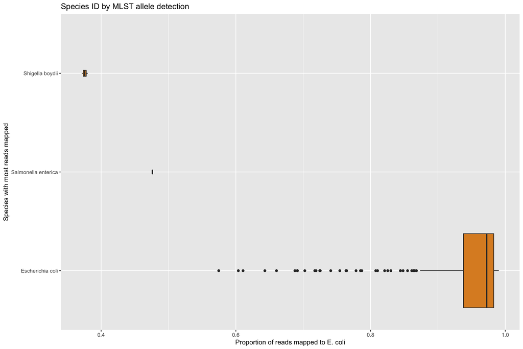

```r
#Make a figure with two box plots showing proportion of reads mapping to E. coli,
#whtehr they were detected as E. coli by MLST on the X axis.

g <- ggplot(QC_data, mapping = aes(x = `Escherichia coli`, y = top_species))

p <- g + geom_boxplot(varwidth=T, fill="#DD8D29") +
        labs(title="Species ID by MLST allele detection",
             x="Proportion of reads mapped to E. coli",
             y="Species with most reads mapped")

p
```

Next we look at genome sizes.

```r
#Read in our assembly stats data
assembly_stats <- read_delim(
        assembly_stats_path,
        "\t",
        escape_double = FALSE,
        trim_ws = TRUE,
        show_col_types = FALSE
)

#Read in data from NCBI with taxID/scientific name conversions
taxid_names <- read_delim(
        tax_id_converter_path,
        "|",
        escape_double = FALSE,
        trim_ws = TRUE,
        show_col_types = FALSE
)

#Read in data from NCBI with expected species genome sizes
genome_size <- read_delim(
        genome_sizes_path,
        "\t",
        escape_double = FALSE,
        trim_ws = TRUE,
        show_col_types = FALSE
)

#Rename the column to simplify it and remove illegal character
genome_size <- genome_size %>% rename('taxid' = '#species_taxid')

#Join our two NCBI tables
expected_genome_size <-
        inner_join(genome_size, taxid_names, by = "taxid")

#rename our column to facilitate a join later on
expected_genome_size <-
        expected_genome_size %>% rename('top_species' = 'taxname')


#Remove anything with the word "Virus" which breaks our size ranges later
expected_genome_size <- expected_genome_size %>% filter(!grepl("virus", top_species))

#Remove unwanted brackets in species name
expected_genome_size$top_species <-
        gsub("\\[", "", expected_genome_size$top_species)
expected_genome_size$top_species <-
        gsub("\\]", "", expected_genome_size$top_species)

#Create a top genus column
expected_genome_size$genus <-
        gsub(" .*", "", expected_genome_size$top_species)

#Create a df of expected genus genome sizes (rather than species)
expected_genus_size <-
        expected_genome_size %>% group_by(genus) %>% summarise(
                `Expected Max Genome Size (Genus)` = max(max_ungapped_length),
                `Expected Min Genome Size (Genus)` = min(min_ungapped_length)
        )

#Bind this new df bcak to our expected genome sizes table
expected_genome_size <-
        inner_join(expected_genome_size, expected_genus_size, by = "genus")

#Separate out the genus related data
expected_genome_size_genus <- expected_genome_size %>% select(genus, `Expected Min Genome Size (Genus)`, `Expected Max Genome Size (Genus)`)

#Remove genus/genus lengths columns - dont need them anymore
expected_genome_size <- expected_genome_size %>% select(-genus, -`Expected Min Genome Size (Genus)`, -`Expected Max Genome Size (Genus)`)

#Join our assembly_stats data with our species ID lists
df <- left_join(assembly_stats, species_IDs, by = "name")

#Remove genera not present in those in our isolates
expected_genome_size_genus <- expected_genome_size_genus %>% filter(genus %in% df$genus)

#Join our expected genome size list (genus) to our assembly stats data
df <-
        left_join(df, expected_genome_size_genus, by = c("genus"))
#Not sure why but we get duplicate rows... Lets remove them
df <- unique(df)

#Join our expected genome size list to our assembly stats data
df <-
        left_join(df, expected_genome_size, by = c("top_species"))

#Generate columns for passed or failed genome sizes
df <-
        df %>% mutate(
                within_species_size = ifelse(
                        total_length > min_ungapped_length*0.95 &
                                total_length < max_ungapped_length*1.05,
                        TRUE,
                        FALSE
                ),
                within_genus_size = ifelse(
                        total_length > `Expected Min Genome Size (Genus)`*0.95 &
                                total_length < `Expected Max Genome Size (Genus)`*1.05,
                        TRUE,
                        FALSE
                )
        )

#Join the new table to our QC data table
QC_data <- QC_data %>% select(-top_species, -`Escherichia coli`, -genus) %>% inner_join(df, by = "name")
```

The following table summarises instances where a genome size outside of the range expected for its species ID.

```r
species_size_fails <- df %>% filter(within_species_size != TRUE)
species_size_fails_table <-  species_size_fails %>% group_by(top_species, within_species_size) %>% summarise("Count" = n(), .groups="keep") %>% arrange(within_species_size, top_species) %>% rename("Species Best Match" = top_species, "Within expected size range (Species)" = within_species_size)

knitr::kable(species_size_fails_table, align = 'c')
```

| Species Best Match | Within expected size range (Species) | Count |
| --- | --- | --- |
| Escherichia coli | FALSE | 5 |

### Contamination screening

Next we will use Bracken data to inform which samples might be contaminated:

```r
#Transform down our bracken data
melt_bracken <- reshape2::melt(bracken, id.vars = 'name')

#Reassign our column names
colnames(melt_bracken) <- c('name', 'species', 'read_proportion')

#Get rid of annoying characters in our species names
melt_bracken$species <- gsub("\\]", "", melt_bracken$species)
melt_bracken$species <- gsub("\\[", "", melt_bracken$species)

#Create a column for genus
melt_bracken$genus <- melt_bracken$species

#Remove everything after genus name
melt_bracken$genus <- gsub(" .*", "", melt_bracken$genus)

#Convert the proportion of reads associated with a given genus/species to a numeric
suppressWarnings(melt_bracken$read_proportion <-
        as.numeric(melt_bracken$read_proportion))

#Replace NAs with 0s (not all genomes hit all species/genera)
melt_bracken$read_proportion[is.na(melt_bracken$read_proportion)] <-
        0
```

We will start by checking the genomes which we think are contaminated based on them having genome sizes outside of the range expected for their respective species. Note that we remove noise in the data by only considering species/genus matches which account for 5% or more of the reads

Below you can see the proportion of reads from a given sample mapping to a species from the Kraken2 database (processed using Bracken).

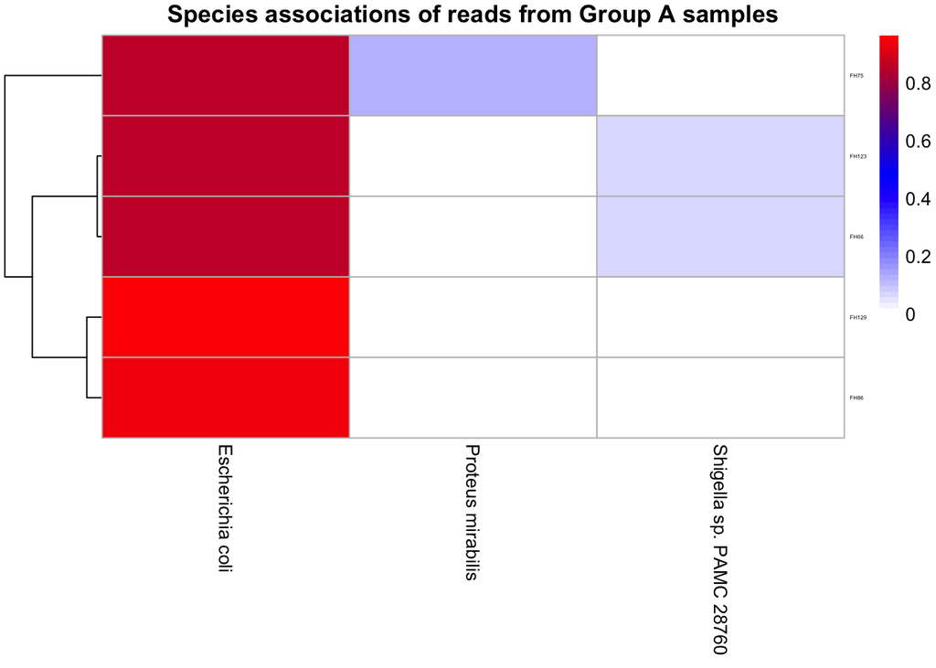

```r
#Create a list of genomes which had genome lengths outside the expected range for their species
species_genome_size_fails <- species_size_fails %>% filter(within_species_size == FALSE)

#Create a list of genomes which were of a species not represented in refseq (and therefore missing an expected genome size)
species_genome_size_missing <- species_size_fails %>% filter(is.na(within_species_size))


BCO_APEC_bracken <-
        bracken %>% filter(name %in% species_genome_size_fails$name) %>% select(-top_species,-name)

BCO_APEC_bracken[BCO_APEC_bracken < 0.05] <- 0

i <- (colSums(BCO_APEC_bracken, na.rm = T) != 0)

BCO_APEC_bracken <- BCO_APEC_bracken[, i]

pheatmap(
        BCO_APEC_bracken,
        fontsize_row = 3,
        fontsize_col = 10,
        cluster_cols = FALSE,
        color = colorRampPalette(c("white", "blue", "red"))(50),
        border_color = "grey",
        main = "Species associations of reads from Group A samples",
        display_numbers = FALSE
)
```

Now lets work out how many samples are:

- *E. coli* (>= 50% of the reads being *E. coli* and MLST scheme auto-detection being *E. coli*)
- Of an appropriate size for the species (Based on Assembly stats and Bracken ID)
- Sufficiently pure (<= 10% contamination from CheckM)
- Sufficiently complete (>= 90% completeness from CheckM)

```r
#Combine our assembly stats, genome sizes and bracken data
checkm_qa <- read_delim(checkm_path,
    delim = "\t", escape_double = FALSE,
    trim_ws = TRUE, show_col_types = FALSE)

#Rename our ID column
checkm_qa <- checkm_qa %>% rename(name = `Bin Id`)

#Combine our bracken data
QC_data <- left_join(QC_data, checkm_qa, by = "name")

#Create our table of QC pass/fails
tablesss <- QC_data %>% group_by(`Escherichia coli` > 0.5 & scheme == "ecoli", name %nin% species_size_fails$name, Contamination > 10, Completeness > 90) %>% summarise(counts = n(), .groups="keep")

colnames(tablesss) <- c('E. coli', 'Appropriate size', "Contaminated", "Complete", "Count")

knitr::kable(tablesss, align = 'c')
```

| E. coli | Appropriate size | Contaminated | Complete | Count |
| --- | --- | --- | --- | --- |
| FALSE | FALSE | FALSE | FALSE | 1 |
| FALSE | FALSE | TRUE | TRUE | 1 |
| FALSE | TRUE | FALSE | TRUE | 3 |
| TRUE | FALSE | TRUE | TRUE | 3 |
| TRUE | TRUE | FALSE | TRUE | 300 |
| TRUE | TRUE | TRUE | TRUE | 1 |

### Genome contiguity

Lastly lets check for contiguity of the genomes.

We will require our genomes to have an N50 of > 15,000 and fewer than 800 scaffolds.

```r
#Generate a table of the genomes which do and don't meet our contiguity criteria
contiguity_table <- QC_data %>% group_by(N50 > 15000, number < 800) %>% summarise(counts = n(), .groups="keep")

#Rename our columns
contiguity_table <- contiguity_table %>% rename("Scaffold count < 800" = `number < 800`)

#Plot the table
knitr::kable(contiguity_table, align = 'c')
```

| N50 > 15000 | Scaffold count < 800 | counts |
| --- | --- | --- |
| FALSE | FALSE | 3 |
| TRUE | FALSE | 1 |
| TRUE | TRUE | 305 |

Now lets show below the count of samples which met or didn’t meet our QC criteria:

```r
#Generate a table of genomes which passed QC
pass_QC_table <- QC_data %>% group_by(`Escherichia coli` > 0.5 & scheme == "ecoli", name %nin% species_size_fails$name, Contamination > 10, Completeness > 90, N50 > 15000, number < 800) %>% summarise(counts = n(), .groups="keep")

#Rename our columns
colnames(pass_QC_table) <- c('E. coli', 'Appropriate size', "Contaminated", "Complete", "Count", "N50 > 15,000", "Scaffold count < 800")

#Generate our list of samples which pass QC
QC_pass <- QC_data %>% filter(`Escherichia coli` > 0.5 & scheme == "ecoli", name %nin% species_size_fails$name, Contamination < 10, Completeness > 90, N50 > 15000, number < 800) %>% select(name)

#Add a column for if the strains passed our QC or not
QC_data <- QC_data %>% mutate(QC_status = if_else(name %in% QC_pass$name, "Pass", "Fail"))

#Write the names of the samples which passed QC
#write_delim(QC_pass, "delims/QC_data.txt", delim = "\t")

#Write the names of the samples which passed QC
#write_delim(QC_pass, "delims/QC_pass.txt")

#Plot our table
knitr::kable(pass_QC_table, align = 'c')
```

| E. coli | Appropriate size | Contaminated | Complete | Count | N50 > 15,000 | Scaffold count < 800 |
| --- | --- | --- | --- | --- | --- | --- |
| FALSE | FALSE | FALSE | FALSE | TRUE | TRUE | 1 |
| FALSE | FALSE | TRUE | TRUE | FALSE | FALSE | 1 |
| FALSE | TRUE | FALSE | TRUE | TRUE | TRUE | 3 |
| TRUE | FALSE | TRUE | TRUE | FALSE | FALSE | 1 |
| TRUE | FALSE | TRUE | TRUE | TRUE | FALSE | 1 |
| TRUE | FALSE | TRUE | TRUE | TRUE | TRUE | 1 |
| TRUE | TRUE | FALSE | TRUE | TRUE | TRUE | 300 |
| TRUE | TRUE | TRUE | TRUE | FALSE | FALSE | 1 |

### Preliminary Phylogeny

Lastly we create a preliminary phylogeny of our genomes higlighting those which passed QC and those which did not.

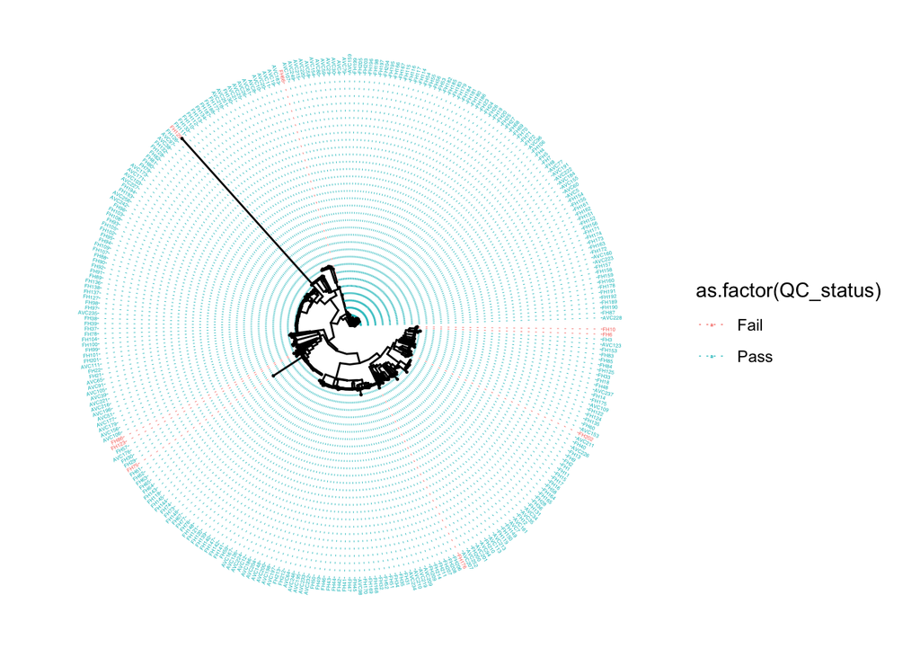

```r
#Read in our tree
tree <- read.tree(tree_path)

#Rename our tips to trim off the ".R1"
tree$tip.label <- gsub(".R1$","",tree$tip.label)

#Select the columns we want from our QC dataframe
small_QC_df <- QC_data %>% select(name, within_species_size, ST, top_species, Contamination, Completeness, QC_status)

p2 <- ggtree(tree, layout = "circular", open.angle = 0) %<+%
        small_QC_df +
        geom_tiplab(size = 1,
                align = TRUE,
                linesize = 0.15,
                aes(color = as.factor(QC_status))
                ) +
        geom_tippoint(size = 0.2#,
                #aes(colour = as.factor(mytipcolvar))
                )

p2
```

## Remove Duplicates

Some strains were collected from different sites in the same bird. To address this and reduce bias in statistical analyses, samples collected from the same bird were removed such that only one isolate from a given host remained. Samples were prioritised from bone sites.

Code used to randomly select a strain from a given host can be seen in the code block below.

```r
metadata <- read_delim("delims/merged_metadata.txt", delim = "\t", show_col_types = FALSE)

metadata <- metadata %>% rename('name' = `Sample Name`, 'site' = `Plate Label - Site of isolation`)

metadata <- metadata %>% filter(name %in% QC_pass$name)

site_table <- metadata %>% group_by(site) %>% tally(sort = TRUE)

bone_sites <- c(
        "RTT",
        "LFH",
        "RFH",
        "LTT",
        "RHSF",
        "LHSF",
        #"LIVER",
        #"YS",
        #"Liver",
        #"PERICARDITIS",
        #"PERITONITIS",
        "RFHSF",
        #"ACCETABULUM",
        #"HB",
        "LTTJF",
        "LTTSF",
        #"Lung 1",
        #"Lung 2",
        #"NAVEL",
        #"PERICARD FLUID",
        #"PERICARDIUM",
        "RFHJF",
        "RHJF",
        "RKSF",
        "RTTSF"#,
        #"SKIN"
)

metadata <- metadata %>% mutate(bone_site = if_else(site %in% bone_sites, "bone", "other"))

set.seed(1)

sample_bone_sites <- metadata %>% filter(bone_site == "bone") %>% group_by(Bird_Gross_Necropsy_ID) %>% slice_sample(n = 1) %>% pull(name) %>% as.data.frame() %>% rename("name" = ".")

#write_delim(sample_bone_sites, "delims/sampled_bone_site_names.txt", delim = "\t")
```